# Download e manipulaçao de dados ERA5

https://www.ecmwf.int/en/forecasts/datasets/reanalysis-datasets/era5

- ERA5 é a uma reanálise (quinta geraçao) do centro Europeu ECMWF (European Centre for Medium-Range Weather Forecasts), produzida pelo C3S (Copernicus Climate Change Service)
- ERA5 substitui a reanálise ERA-Interim (que terminou a 31 de agosto de 2019)
- periodo 1950 até ao presente (1950 a 1978 = back extension dataset)
- dados horários e médias mensais de atmosfera, solo e oceano
- grelha de 30 km, 137 níveis verticais (superfície até 80 km)
- dados disponíveis em nívies individuais; níveis de pressao, temperatura potencial e vorticidade; níveis do modelo

### Obter os dados

https://cds.climate.copernicus.eu/cdsapp#!/search?type=dataset

- pesquisar **era5**
- seleccionar **ERA5 hourly data on single levels from 1979 to present**

[figure not shown]

- login
- seleccionar **Download data**

[figure not shown]

- seleccionar variável (ex **2m temperature**)
- seleccionar ano, mês, dia e horas (ex 2021, Dezembro, todos os dias, horas 0, 6, 12 e 18)
- seleccionar regiao
- seleccionar formato (ex NetCDF)
- **1) Submit form** ou **2) Show API request**

**1) resultado:** adaptor.mars.internal-1652089044.5537355-12118-18-4874488a-8820-4ad3-9b8d-b58c0896c78a.nc

#### 2) API request

```
import cdsapi

c = cdsapi.Client()

c.retrieve(
    'reanalysis-era5-single-levels',
    {
        'product_type': 'reanalysis',
        'variable': '2m_temperature',
        'year': '2021',
        'month': '12',
        'day': [
            '01', '02', '03',
            '04', '05', '06',
            '07', '08', '09',
            '10', '11', '12',
            '13', '14', '15',
            '16', '17', '18',
            '19', '20', '21',
            '22', '23', '24',
            '25', '26', '27',
            '28', '29', '30',
            '31',
        ],
        'time': [
            '00:00', '06:00', '12:00',
            '18:00',
        ],
        'area': [
            -5, 10, -20,
            25,
        ],
        'format': 'netcdf',
    },
    'download.nc')
```

- gravar como download_era5.py

!python download_era5.py

```
Traceback (most recent call last):
  File "download_era5.py", line 1, in
    import cdsapi
ModuleNotFoundError: No module named 'cdsapi'
```

#### Instalaçao do CDSAPI

(Climate Data Store Application Program Interface) https://cds.climate.copernicus.eu/api-how-to

- criar $HOME/.cdsapirc com:

  ```
  url: https://cds.climate.copernicus.eu/api/v2
  key: 28219:d61c7f68-3eb4-4bbc-9a53-cac297746929
  ```

- pip install cdsapi

!python download_era5.py

```
2022-05-10 10:59:18,237 INFO Welcome to the CDS
2022-05-10 10:59:18,237 INFO Sending request to https://cds.climate.copernicus.eu/api/v2/resources/reanalysis-era5-single-levels
2022-05-10 10:59:18,499 INFO Request is queued
2022-05-10 10:59:21,170 INFO Request is running
2022-05-10 10:59:32,117 INFO Request is completed
2022-05-10 10:59:32,118 INFO Downloading https://download-0004-clone.copernicus-climate.eu/cache-compute-0004/cache/data5/adaptor.mars.internal-1652176766.6268768-3639-12-1b9b7a10-2da3-49d7-8c84-34234fa80212.nc to download.nc (903.2K)
2022-05-10 10:59:33,212 INFO Download rate 825.6K/s
```

```python
!ls -lh download.nc
!mv download.nc data/era5/
```

```
-rw-rw-r--. 1 mma mma 904K May 10 10:59 download.nc
```

### Conteúdo do ficheiro netcdf

- atributos (globais)
- dimensoes
- variáveis (contêm dimensao, tipo de dados e atributos)

```python
f='data/era5/download.nc'
import netCDF4
nc=netCDF4.Dataset(f)

print('Variables:')
for vname in nc.variables:
    print('-- %s: %s'%(vname,nc.variables[vname].shape))

print('Dimensions:')
for dname in nc.dimensions:
    print('-- %-10s %s'%(dname,nc.dimensions[dname].size))
```

```
Variables:
-- longitude: (61,)
-- latitude: (61,)
-- time: (124,)
-- t2m: (124, 61, 61)
Dimensions:
-- longitude  61
-- latitude   61
-- time       124
```

```python
from ferramentas import ncshow
ncshow(f)
```

```
# Contents of the NetCDF file
   data/era5/download.nc

:: Global Attributes:
   Conventions  CF-1.6
   history      2022-05-10 09:59:27 GMT by grib_to_netcdf-2.24.3: /opt/ecmwf/mars-cli+

:: Dimensions:
   longitude   61
   latitude    61
   time       124

:: Variables:
                    long_name                      units                     shape
   longitude | longitude           | degrees_east                      | (61,)         |
   latitude  | latitude            | degrees_north                     | (61,)         |
   time      | time                | hours since 1900-01-01 00:00:00.0 | (124,)        |
   t2m       | 2 metre temperature | K                                 | (124, 61, 61) |
```

### Leitura do tempo

```python
import warnings
warnings.filterwarnings('ignore')

t=nc.variables['time']
print('Atributos da variavel time:')
for aname in t.ncattrs():
    print('-- %s: %s'%(aname,getattr(t,aname)))
```

```
Atributos da variavel time:
-- units: hours since 1900-01-01 00:00:00.0
-- long_name: time
-- calendar: gregorian
```

```python
t[:10]
```

```
masked_array(data=[1068696, 1068702, 1068708, 1068714, 1068720, 1068726,
                   1068732, 1068738, 1068744, 1068750],
             mask=False,
       fill_value=999999,
            dtype=int32)
```

horas desde 1900 no calendário gregoriano (o calendário "normal").

Como converter para uma data (datetime)?

```python
from cftime import num2date
datas=num2date(t[:],t.units,t.calendar)
datas[:10]
```

```
array([datetime.datetime(2021, 12, 1, 0, 0),
       datetime.datetime(2021, 12, 1, 6, 0),
       datetime.datetime(2021, 12, 1, 12, 0),
       datetime.datetime(2021, 12, 1, 18, 0),
       datetime.datetime(2021, 12, 2, 0, 0),
       datetime.datetime(2021, 12, 2, 6, 0),
       datetime.datetime(2021, 12, 2, 12, 0),
       datetime.datetime(2021, 12, 2, 18, 0),
       datetime.datetime(2021, 12, 3, 0, 0),
       datetime.datetime(2021, 12, 3, 6, 0)], dtype=object)
```

### Visualizaçao

```python
import pylab as pl

x=nc.variables['longitude'][:]
y=nc.variables['latitude'][:]
v=nc.variables['t2m'][:]-273.15

fig,ax = pl.subplots(ncols=5,nrows=1,figsize=(12,12))

for i in range(5):
    it=i*7*4+2
    h=ax[i].pcolormesh(x,y,v[it],vmin=20,vmax=30)
    ax[i].set_title(datas[it])
    ax[i].axis('image')

pl.subplots_adjust(wspace=0.4)
pl.colorbar(h,ax=ax,shrink=0.4, location='bottom',pad=0.04);
```

[output not shown]

#### adicionar informaçao geográfica

```
'0.18.0'
```

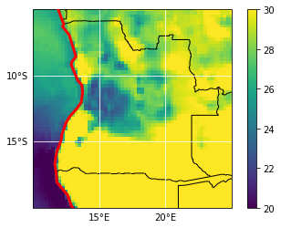

```python
import cartopy.crs as ccrs
import cartopy
m=ccrs.PlateCarree() # proj cilindrica (lon,lat, eixos iguais)

fig=pl.figure()
ax=pl.axes(projection=m)

ax.set_extent((10,25,-20,-5))
h=ax.pcolormesh(x,y,v[it],vmin=20,vmax=30)
pl.colorbar(h,location='right')

# fronteiras de paises:
ax.add_feature(cartopy.feature.BORDERS,edgecolor='black',facecolor='none',lw=1)

# linha de costa:
#ax.coastlines(color='red',lw=2)

ax.add_feature(cartopy.feature.LAND.with_scale('110m'),edgecolor='red',facecolor='none',lw=3,zorder=1e3)

# gridlines:
gl=ax.gridlines(color='w',draw_labels=1,xlocs=range(-20,30,5),ylocs=range(-30,0,5))
gl.right_labels=False
gl.top_labels=0

# mudar limites:
#ax.set_extent((5,30,-25,-0))
cartopy.__version__
```

#### outras projecçoes mais "úteis"

- projecçao corformal de Lambert (adicionar proj no axes e proj original no plot)

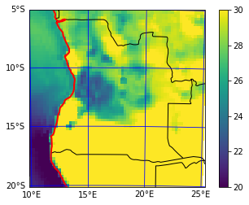

```python
import cartopy.crs as ccrs
import cartopy

m=ccrs.LambertConformal(central_longitude=15, central_latitude=-15,
                        secant_latitudes=[-20,5], cutoff=30)

fig=pl.figure()
ax=pl.axes(projection=m)

ax.set_extent((10,25,-20,-5))
h=ax.pcolormesh(x,y,v[it],vmin=20,vmax=30,transform=ccrs.PlateCarree())
pl.colorbar(h,location='right')

# fronteiras de paises:
ax.add_feature(cartopy.feature.BORDERS,edgecolor='black',facecolor='none',lw=1)

# linha de costa:
ax.coastlines(color='red',lw=2)

# gridlines:
gl=ax.gridlines(color='b',draw_labels=1,xlocs=range(-20,30,5),ylocs=range(-30,0,5),x_inline=False, y_inline=False)
gl.right_labels=False
gl.top_labels=False

# mudar limites:
#ax.set_extent((-30,50,-35,-0))
```

```
FOUND AGO <class 'shapely.geometry.multipolygon.MultiPolygon'>
```

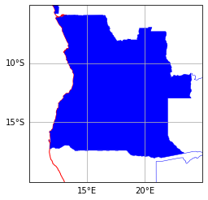

```python
import warnings
warnings.filterwarnings('ignore')



m=ccrs.Mercator()
fig=pl.figure()
ax=pl.axes(projection=m)

ax.set_extent((10,25,-20,-5))

resol='10m'
# countries:
ax.add_feature(cartopy.feature.BORDERS,edgecolor='blue',facecolor='none',lw=0.5,zorder=2)
# coast:
ax.coastlines(resolution=resol,color='red')
gl=ax.gridlines(draw_labels=1,xlocs=range(-20,30,5),ylocs=range(-30,0,5))
gl.right_labels=False
gl.top_labels=False



#h=ax.pcolormesh(x,y,v,transform=ccrs.PlateCarree())
#pl.colorbar(h)

t=nc.variables['time'][:]
nc.variables['time'].units

import cartopy.io.shapereader as shpreader
#cat='cultural'
#resol='110m'
#shapename='admin_0_boundary_lines_land'
#states_shp = shpreader.natural_earth(resolution=resol,category=cat, name=shapename)
#
#for astate in shpreader.Reader(states_shp).records():
#    cor='#ba0000'
#    cor='#0c6100'
#    if astate.attributes['adm0_left']=='Angola':# or astate.attributes['adm0_right']=='Brazil':
#      ax.add_geometries([astate.geometry], ccrs.PlateCarree(),facecolor='none', edgecolor=cor,lw=0.75,zorder=2.1)


shpfilename = shpreader.natural_earth(resolution='10m',
                                      category='cultural',
                                      name='admin_0_countries')
reader = shpreader.Reader(shpfilename)
countries = reader.records()

for country in countries:
    #print('===%s=='%country.attributes['NAME_PT'],country.attributes['NAME_PT'] == 'Angola',type(country.attributes['NAME_PT']))
    if country.attributes['NAME_PT'].startswith('Angola'):
        print('FOUND',country.attributes['ADM0_A3'],type(country.geometry))
        ax.add_geometries(country.geometry, ccrs.PlateCarree(),
                          facecolor=(0, 0, 1))#,
                          #label=country.attributes['ADM0_A3'])
        p=country.geometry
        break
        #h=ax.pcolormesh(x,y,v,transform=ccrs.PlateCarree(),clip_path=p)
    else:pass
        #ax.add_geometries(country.geometry, ccrs.PlateCarree(),
         #                 facecolor=(0, 1, 0),
          #                label=country.attributes['ADM0_A3'])
```

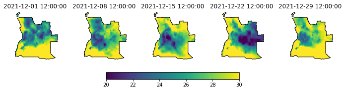

```python
type(country.geometry)
from matplotlib.path import Path
q=country.geometry
len(q)
type(q[0])

def poly2path(mpoly,trans=False):
    vertices=[]
    codes=[]
    for polygon in mpoly:
        if trans:
            coords=[trans.transform_point(i[0],i[1],ccrs.PlateCarree()) for i in polygon.exterior.coords]
        else:
            coords=list(polygon.exterior.coords)

        vertices += coords
        codes += [Path.MOVETO if i == 0 else Path.LINETO
                  for i in range(len(coords))]

        for interior in polygon.interiors:
            if trans:
                coords=[trans.transform_point(i[0],i[1],ccrs.PlateCarree()) for i in polygon.exterior.coords]
            else:
                coords=list(interior.coords)

            vertices += coords
            codes += [Path.MOVETO if i == 0 else Path.LINETO
                      for i in range(len(coords))]

    return Path(vertices, codes)

if 0:
    fig=pl.figure()
    ax=pl.axes()
    #ax=pl.axes(projection=m)
    p=poly2path(country.geometry)
    ax.pcolormesh(x,y,v,clip_path=(p,ax.transData))
    #h=ax.pcolormesh(x,y,v,transform=ccrs.PlateCarree(),clip_path=p)

#fig=pl.figure()
m=ccrs.PlateCarree()
m=ccrs.Mercator()

#ax=pl.axes(projection=m)
fig,ax = pl.subplots(ncols=5,nrows=1,figsize=(12,12),
                      subplot_kw={'projection': m})


p=poly2path(country.geometry,trans=m)
#h=ax.pcolormesh(x,y,v,transform=ccrs.PlateCarree(),clip_path=(p,m.transData))
w=m.transform_points(ccrs.PlateCarree(),x,y)
xx=w[:,0]
yy=w[:,1]
yy.shape
y.shape

import matplotlib.patches as patches
patch = patches.PathPatch(p, edgecolor='black', facecolor='none',lw=1)

from copy import copy

for i in range(5):
    it=i*7*4+2
    h=ax[i].pcolormesh(xx,yy,v[it],transform=m,clip_path=(p,ax[i].transData),vmin=20,vmax=30)
    ax[i].set_frame_on(0)
    new_patch=copy(patch)
    ax[i].add_patch(new_patch)
    ax[i].set_title(datas[it])

pl.colorbar(h,ax=ax,shrink=0.4, location='bottom',pad=0.01);
```

### Anomalia temporal

- retirando a média mensal: **v.mean(0)**

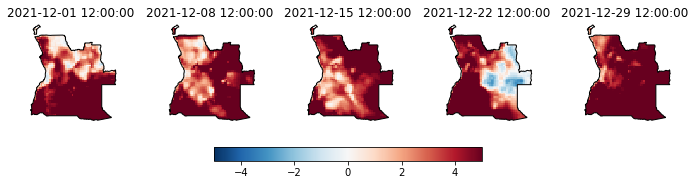

```python
fig,ax = pl.subplots(ncols=5,nrows=1,figsize=(12,12),
                      subplot_kw={'projection': m})

for i in range(5):
    it=i*7*4+2
    h=ax[i].pcolormesh(xx,yy,v[it]-v.mean(0),transform=m,clip_path=(p,ax[i].transData),
                       vmin=-5,vmax=5,cmap='RdBu_r')
    ax[i].set_frame_on(0)
    new_patch=copy(patch)
    ax[i].add_patch(new_patch)
    ax[i].set_title(datas[it])

pl.colorbar(h,ax=ax,shrink=0.4, location='bottom',pad=0.01);
```

- retirando a média mensal das 12h: **v[2::4].mean(0)**

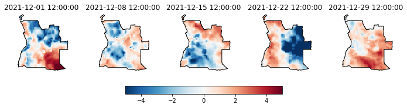

```python
fig,ax = pl.subplots(ncols=5,nrows=1,figsize=(12,12),
                      subplot_kw={'projection': m})

for i in range(5):
    it=i*7*4+2
    h=ax[i].pcolormesh(xx,yy,v[it]-v[2::4].mean(0),transform=m,clip_path=(p,ax[i].transData),
                       vmin=-5,vmax=5,cmap='RdBu_r')
    ax[i].set_frame_on(0)
    new_patch=copy(patch)
    ax[i].add_patch(new_patch)
    ax[i].set_title(datas[it])

pl.colorbar(h,ax=ax,shrink=0.4, location='bottom',pad=0.01);
```

### Média/Anomalia espacial

- encontrar pontos dentro do dimínio de interesse!!

```python
from shapely.geometry import Point
country.geometry.contains

X,Y=np.meshgrid(x,y)
nlat,nlon=X.shape
cond=np.zeros((nlat,nlon),dtype='bool')
for j in range(nlat):
    for i in range(nlon):
        cond[j,i]=country.geometry.contains(Point(X[j,i],Y[j,i]))
```

[figure not shown]

```python
pl.figure(figsize=(6,6))
pl.plot(X,Y,'r.',ms=1)
pl.plot(X[cond],Y[cond],'bo',ms=3);
```

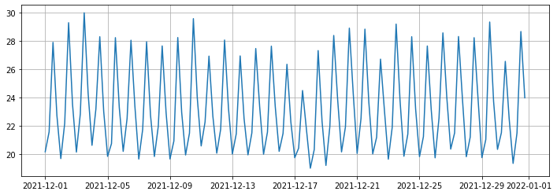

```python
pl.figure(figsize=(12,4))
ax=pl.axes()
ax.plot(datas,v[:,cond].mean(-1));
ax.grid(1)
```

- comparar Luanda com média espacial:

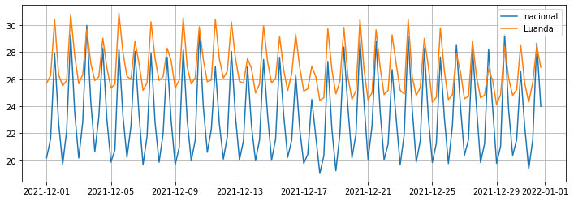

```python
x0=13.234444
y0=-8.838333
dist=(X-x0)**2+(Y-y0)**2
j,i=np.where(dist==dist.min())
j=j[0]
i=i[0]

pl.figure(figsize=(12,4))
ax=pl.axes()
ax.plot(datas,v[:,cond].mean(-1),label='nacional'); # pq mena(-1) ? Qual a dimensao de v[:,cond]??
ax.grid(1)

ax.plot(datas,v[:,j,i],label='Luanda');
pl.legend()
```

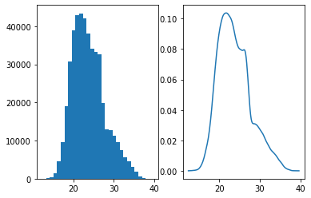

```python
import numpy as np
import scipy.stats

v.shape=v.size

q = scipy.stats.kde.gaussian_kde(v)
x=np.linspace(v.min(),v.max(),200)

fig,ax=pl.subplots(1,2)
ax[0].hist(v,30)
ax[1].plot(x,q(x))
```